# Shahid Bike_Share_Analysis(2)

## Performing My Own Analysis

**My Questions**:

What is the busiest hour for bike share system in each city?  
What is the most busy day of week for bike share system in each city?  
What is the busiest bike share station in each city?  
How do the customers and subscribers vary throughout the year? Answer this by drawing a distribution of subscribers and customers for each city.  
What is the most busiest month in each city?

**Answer**:

```python
"""
    This function returns the most busy hour for the given city
"""
def find_busy_hour(file):

    ##declare a dictionary that will record what is the count of hours
    ##in which user has used bike share system
    hour_count_dict = {}

    ##declare variables that will count most busy hour and total customers that used bike in that hour
    busy_hour = 0
    total_cus = 0

    with open(file) as f_in:
        reader = csv.DictReader(f_in)
        for row in reader:

            ##get the hour from each entry and store it in variable k
            k = row['hour']
            if k in hour_count_dict:
                hour_count_dict[k] += 1
            else:
                hour_count_dict[k] = 1

    ##to get the most busy hour from the above dictionary and return it
    ##each dictionary item is a tuple and contains a key and a value
    ##we will compare the values one by one and keeping updatng the busy_hour variable
    ##with largest dictionary value
    for x in hour_count_dict.items():
        if x[1] > total_cus:
            busy_hour = x[0]
            total_cus = x[1]

    return busy_hour
```

```python
"""
    Find busy hour of bike share system for Chicago , NYC and Washington
"""
busy_hour = find_busy_hour('./data/Chicago-2016-Summary.csv')
print("Most busy hour in Chicago for bike share system is hour {}".format(busy_hour))
busy_hour = find_busy_hour('./data/NYC-2016-Summary.csv')
print("Most busy hour in NYC for bike share system is hour {}".format(busy_hour))
busy_hour = find_busy_hour('./data/Washington-2016-Summary.csv')
print("Most busy hour in Washington for bike share system is hour {}".format(busy_hour))
```

```
Most busy hour in Chicago for bike share system is hour 17
Most busy hour in NYC for bike share system is hour 17
Most busy hour in Washington for bike share system is hour 17
```

```python
"""
    This function returns the most busy day of the week for the given city
"""
def find_busiest_day(file):

    ##declare a dictionary that will record what is the count of days
    ##in which user has used bike share system
    day_count_dict = {}

    ##declare variables that will count most busy hour and total customers that used bike in that hour
    busy_day = 0
    total_cus = 0

    with open(file) as f_in:
        reader = csv.DictReader(f_in)
        for row in reader:

            ##get the day of week from the user row of file and store in variable k
            k = row['day_of_week']
            if k in day_count_dict:
                day_count_dict[k] += 1
            else:
                day_count_dict[k] = 1

    ##to get the most busy day from the above dictionary and return it
    ##each dictionary item is a tuple and contains a key and a value
    ##we will compare the values one by one and keeping updatng the busy_hour variable
    ##with largest dictionary value
    for x in day_count_dict.items():
        if x[1] > total_cus:
            busy_day = x[0]
            total_cus = x[1]

    return busy_day
```

```python
"""
    Find busy hour of bike share system for Chicago , NYC and Washington
"""
busy_hour = find_busiest_day('./data/Chicago-2016-Summary.csv')
print("Most busy day in Chicago for bike share system is {}".format(busy_hour))
busy_hour = find_busiest_day('./data/NYC-2016-Summary.csv')
print("Most busy day in NYC for bike share system is {}".format(busy_hour))
busy_hour = find_busiest_day('./data/Washington-2016-Summary.csv')
print("Most busy day in Washington for bike share system is {}".format(busy_hour))
```

```
Most busy day in Chicago for bike share system is Monday
Most busy day in NYC for bike share system is Wednesday
Most busy day in Washington for bike share system is Wednesday
```

```python
"""
    This function returns the most busy bike share station for the given city
"""
def most_busy_station(file):

    ##get the city name from filename
    city = file.split('-')[0].split('/')[-1]

    ##declare a dictionary that will record what is the count of days
    ##in which user has used bike share system
    station_count_dict = {}

    ##declare variables to record the most busiest station and total customers that used that station
    busy_station = ''
    total_cus = 0

    with open(file) as f_in:
        reader = csv.DictReader(f_in)

        ##in this function we will use the old datasets
        ##we will get the start station name and end station name
        ##for the user in the given city and store in variables k and t
        for row in reader:
            if city == 'NYC':
                k = row['start station name']
                t = row ['end station name']
            elif city == 'Chicago':
                k = row['from_station_name']
                t = row['to_station_name']
            else:
                k = row['Start station']
                t = row['End station']

            ##adding station names to dictionary and incrementing the count
            ##if it already exists in dictionary
            if k in station_count_dict:
                station_count_dict[k] += 1
            else:
                station_count_dict[k] = 1

            if t in station_count_dict:
                station_count_dict[t] += 1
            else:
                station_count_dict[t] = 1

    ##to get the most busy station from the above dictionary and return it
    ##each dictionary item is a tuple and contains a key and a value
    ##we will compare the values one by one and keeping updatng the busy_hour variable
    ##with largest dictionary value

    for x in station_count_dict.items():
        list(x)
        if x[1] > total_cus:
            busy_station = x[0]
            total_cus = x[1]

    return busy_station
```

```python
"""
    Find busy station of bike share system for Chicago , NYC and Washington
"""
busy_station = most_busy_station('./data/Chicago-Divvy-2016.csv')
print("Most busy station in Chicago for bike share system is  {}".format(busy_station))
busy_station = most_busy_station('./data/NYC-CitiBike-2016.csv')
print("Most busy station in NYC for bike share system is  {}".format(busy_station))
busy_station = most_busy_station('./data/Washington-CapitalBikeshare-2016.csv')
print("Most busy station in Washington for bike share system is  {}".format(busy_station))
```

```
Most busy station in Chicago for bike share system is  Streeter Dr & Grand Ave
Most busy station in NYC for bike share system is  Pershing Square North
Most busy station in Washington for bike share system is  Columbus Circle / Union Station
```

```python
"""
    This function returns two lists. First list contains months
    in which each subscriber used the bike share system and second
    one return months in which each customer used the bike share system.
"""
def list_of_months(file):

    ##declare two lists to keep record of months in which each subscriber and customer used the bike
    subscriber_month_list = []
    customer_month_list = []
    with open(file) as f_in:
        reader = csv.DictReader(f_in)
        for row in reader:

            ##declare a variable to store month of the user
            k = row['month']

            ##we will check if the user is a subscriber or a customer and update the month lists accordingly
            if row['user_type'] == 'Subscriber':
                subscriber_month_list.append(int(k))
            else:
                customer_month_list.append(int(k))

    return customer_month_list,subscriber_month_list
```

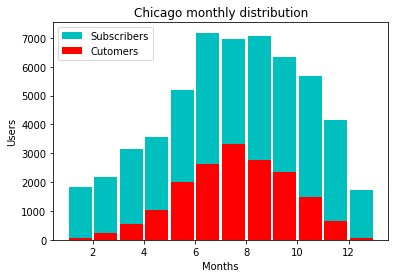

```python
"""
    Histogram of monthly subscribers and customers of Chicago using above created function 'list_of_months'
"""
customer_month_list,subscriber_month_list = list_of_months('./data/Chicago-2016-Summary.csv')
%matplotlib inline
plt.hist(subscriber_month_list,bins = [x for x in range(1,14,1)],rwidth = 0.9,color = 'c',label='Subscribers')
plt.hist(customer_month_list,bins = [x for x in range(1,14,1)],rwidth = 0.9,color = 'r',label='Cutomers')
plt.xlabel('Months')
plt.ylabel('Users')
plt.title('Chicago monthly distribution')
plt.legend()
plt.show()
```

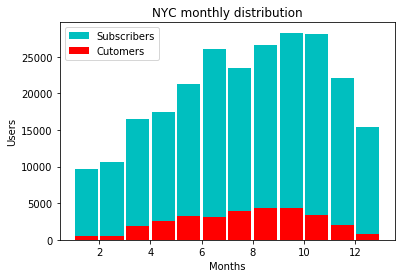

```python
"""
    Histogram of monthly subscribers and customers of NYC
"""
customer_list,subscriber_list = list_of_months('./data/NYC-2016-Summary.csv')
%matplotlib inline
plt.hist(subscriber_list,bins = [x for x in range(1,14,1)],rwidth = 0.9,color = 'c',label='Subscribers')
plt.hist(customer_list,bins = [x for x in range(1,14,1)],rwidth = 0.9,color = 'r',label='Cutomers')
plt.xlabel('Months')
plt.ylabel('Users')
plt.title('NYC monthly distribution')
plt.legend()
plt.show()
```

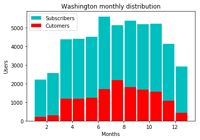

```python
"""
    Histogram monthly subscribers and customers of Washington
"""
customer_list,subscriber_list = list_of_months('./data/Washington-2016-Summary.csv')
%matplotlib inline
plt.hist(subscriber_list,bins = [x for x in range(1,14,1)],rwidth = 0.9,color = 'c',label='Subscribers')
plt.hist(customer_list,bins = [x for x in range(1,14,1)],rwidth = 0.9,color = 'r',label='Cutomers')
plt.xlabel('Months')
plt.ylabel('Users')
plt.title('Washington monthly distribution')
plt.legend()
plt.show()
```

```python
"""
    This function will return the most busiest month of the year for subscribers and customers
"""
def most_busy_month(file):

    ##declare two variables to record the busy month of the year and other one to keep track of users in that month
    busy_month = 0
    users = 0

    ##We will use list_of_months function to get the list of months of subscribers and cutsomers for a given city
    customer_month_list,subscriber_month_list = list_of_months(file)

    ##we will run the for loop 12 times one for each month
    for x in range(1,13):

        ##count frequency of each month i.e number of users in that month
        count_of_users_in_month = customer_month_list.count(x)

        ##we will keep checking for each month if that is most frequent or not
        if users < count_of_users_in_month:
            users  = count_of_users_in_month
            busy_month = x

    return busy_month
```

```python
"""
    Print the most busiest month in each city
"""
busy_month = most_busy_month('./data/Chicago-2016-Summary.csv')
print("Most busy month of the year in Chicago for bike share system is {}th month.".format(busy_month))
busy_month = most_busy_month('./data/NYC-2016-Summary.csv')
print("Most busy month of the year in NYC for bike share system is {}th month.".format(busy_month))
busy_month = most_busy_month('./data/Washington-2016-Summary.csv')
print("Most busy month of the year in Washington for bike share system is {}th month.".format(busy_month))
```

[output not shown]

## Conclusions

**Question 7**: Putting the bike share data aside, think of a topic or field of interest where you would like to be able to apply the techniques of data science. What would you like to be able to learn from your chosen subject?

**Answer**:I would love to apply my data science skills in restaurant analysis of major cities. From this project I would like to be able to learn following things:  
Which is most busiest restaurant in each city and overall?  
What is the most served cusine?  
What is the most and least busiest time to visit a restaurant?  
What is the average number of customers daily?  
What is the most served food in each city?  
What is the average food cost for a restaurant  
Which city has most restaurants?  
Which city has highest percentage of highest rated restaurants?  
What is the average opening and closing time of restaurants in each city?